# Loan Data from Prosper - Part 2

## I. Investigation Overview

In this analysis, we explore the 'Loan Data from Prosper' dataset to uncover insights about loan details and borrower profiles. Our goal is to understand key aspects such as loan amounts, interest rates, and credit grades. We aim to address the following key questions:

1. What are the typical loan amounts, and how do they vary across different credit grades?
2. What is the relationship between loan amounts and borrower APR?
3. Are there any notable patterns in loan amounts based on the listing category or time-related attributes?

Our findings will be supported by professional and polished visualizations that illustrate these patterns and help us gain a deeper understanding of loan trends and borrower profiles.

## II. Dataset Overview

The 'Loan Data from Prosper' dataset provides detailed records of loans, including information about loan amounts, borrower rates, loan statuses, and borrower profiles. The dataset includes the following key attributes:

- **Loan Amount**: The amount of the loan as stated in the dataset.
- **Borrower APR**: The Annual Percentage Rate for the loan.
- **Credit Grade**: The credit rating assigned to the borrower.
- **Listing Category**: The category of the loan listing, such as Debt Consolidation, Home Improvement, etc.

The data allows us to analyze loan characteristics and borrower information to identify trends and patterns.

## III. Visualizations

### A. Distribution of Loan Amounts

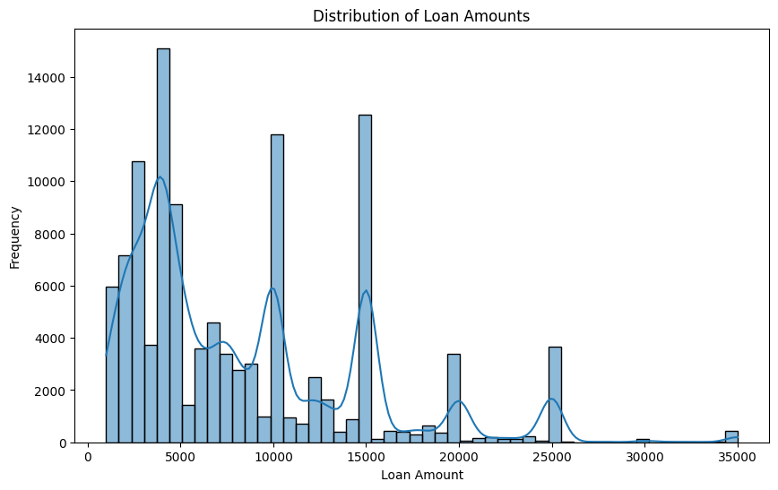

```python
import matplotlib.pyplot as plt
import seaborn as sns
import pandas as pd

# Load the dataset
df = pd.read_csv('prosperLoanData.csv')

# Drop rows where 'LoanOriginalAmount' is NaN
df = df.dropna(subset=['LoanOriginalAmount'])

# Convert 'LoanOriginationDate' to datetime
df['LoanOriginationDate'] = pd.to_datetime(df['LoanOriginationDate'])

# Extract year and month from 'LoanOriginationDate'
df['OriginationYear'] = df['LoanOriginationDate'].dt.year
df['OriginationMonth'] = df['LoanOriginationDate'].dt.month

# Plot distribution of loan amounts
plt.figure(figsize=(10, 6))
sns.histplot(df['LoanOriginalAmount'], bins=50, kde=True)
plt.title('Distribution of Loan Amounts')
plt.xlabel('Loan Amount')
plt.ylabel('Frequency')
plt.show()
```

**Observation:**

The histogram shows that most loans fall within a certain range of amounts, with a few loans having significantly higher values. The distribution may be right-skewed, with fewer high-value loans.

### B. Number of Loans by Credit Grade

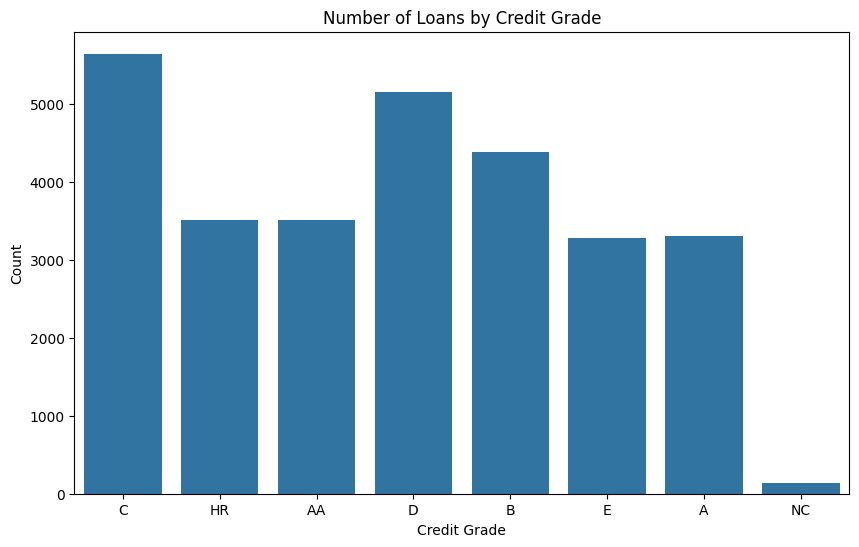

```python
plt.figure(figsize=(10, 6))
sns.countplot(data=df, x='CreditGrade')
plt.title('Number of Loans by Credit Grade')
plt.xlabel('Credit Grade')
plt.ylabel('Count')
plt.show()
```

### C. Loan Amount vs. Borrower APR

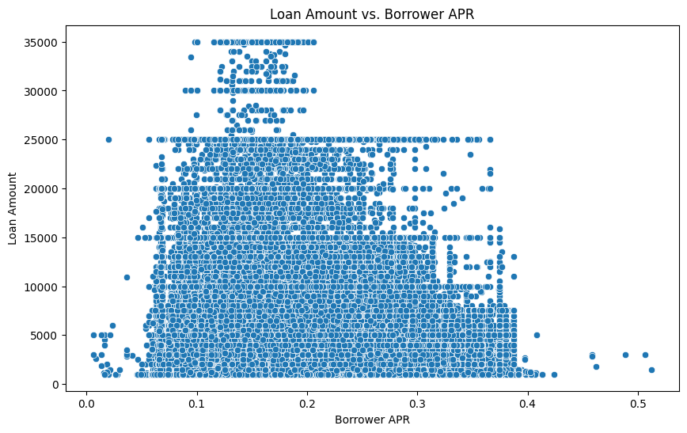

```python
plt.figure(figsize=(10, 6))
sns.scatterplot(x='BorrowerAPR', y='LoanOriginalAmount', data=df)
plt.title('Loan Amount vs. Borrower APR')
plt.xlabel('Borrower APR')
plt.ylabel('Loan Amount')
plt.show()
```

**Observation:**

There may be a correlation between loan amount and borrower APR, with varying patterns across different APR values.

### D. Loan Amount by Listing Category

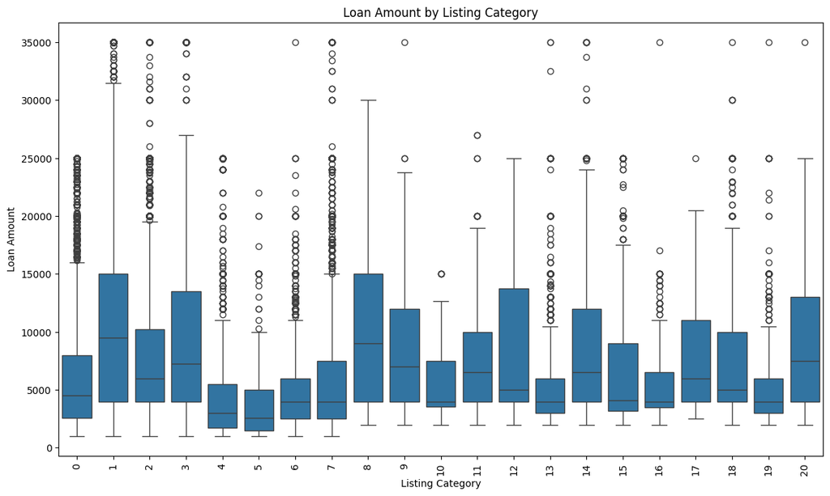

```python
plt.figure(figsize=(14, 8))
sns.boxplot(data=df, x='ListingCategory (numeric)', y='LoanOriginalAmount')
plt.xticks(rotation=90)
plt.title('Loan Amount by Listing Category')
plt.xlabel('Listing Category')
plt.ylabel('Loan Amount')
plt.show()
```

**Observation:**

Loan amounts vary significantly across different listing categories, with some categories showing higher loan amounts on average.

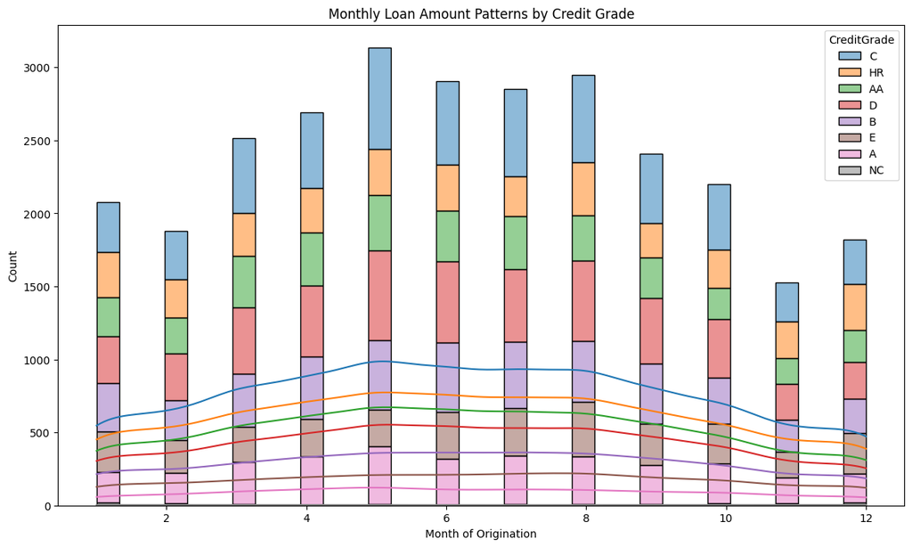

```python
plt.figure(figsize=(14, 8))
sns.histplot(data=df, x='OriginationMonth', hue='CreditGrade', multiple='stack', kde=True)
plt.title('Monthly Loan Amount Patterns by Credit Grade')
plt.xlabel('Month of Origination')
plt.ylabel('Count')
plt.show()
```

## IV. Conclusion

These insights help us understand loan characteristics and borrower profiles, assisting in decision-making and strategy development.